# Data preparation

Camille Crapart

2023-02-21

html version: [Data preparation](https://camilmc.github.io/fCO2/Data_preparation.html)

```r
library(readxl)

library(AquaEnv)
library(MASS)
library(mgcv)
library(dplyr)
```

```r
library(ggplot2)
library(colorspace)

library(sf)
## Linking to GEOS 3.9.3, GDAL 3.5.2, PROJ 8.2.1; sf_use_s2() is TRUE
library(sp)

fCO2.atm.2020 <- 411.51 * 1e-6 # oct 2020
fCO2.atm.2019 <- 408.75 * 1e-6 # oct 2019
fCO2.atm.2004 <- 374.63 * 1e-6 # oct 2004
fCO2.atm.1995 <- 360.17 * 1e-6 # 1995
```

Atmospheric concentration of CO2 is retrieved from: https://climate.nasa.gov/vital-signs/carbon-dioxide/, dataset on https://gml.noaa.gov/webdata/ccgg/trends/co2/co2_mm_mlo.txt

# 1 Data from CBA and N112 surveys

TOC was analysed by infrared CO2 detection after catalytic high temperature combustion (Shimadzu TOC-VWP analyzer) at the Department of Biosciences at the University of Oslo. pH and alkalinity (end-point titration to pH 4.5) were measured at the Chemistry Department of the University of Oslo.

## 1.1 Data from CBA survey

The data is available at Crapart and Parra (2019). Lake area and catchment area were provided by NIVA.

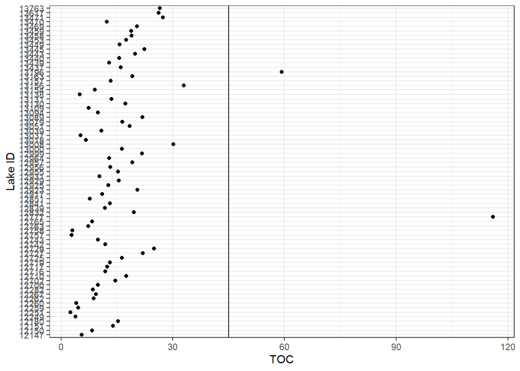

```r
cba.all <- readxl::read_xlsx("CBA_100Lakes_Master.xlsx")

ggplot(cba.all)+geom_point(aes(x = TOC, y = as.character(Lake_ID)))+geom_vline(xintercept = 45)+labs(y="Lake ID")+theme_bw()
```

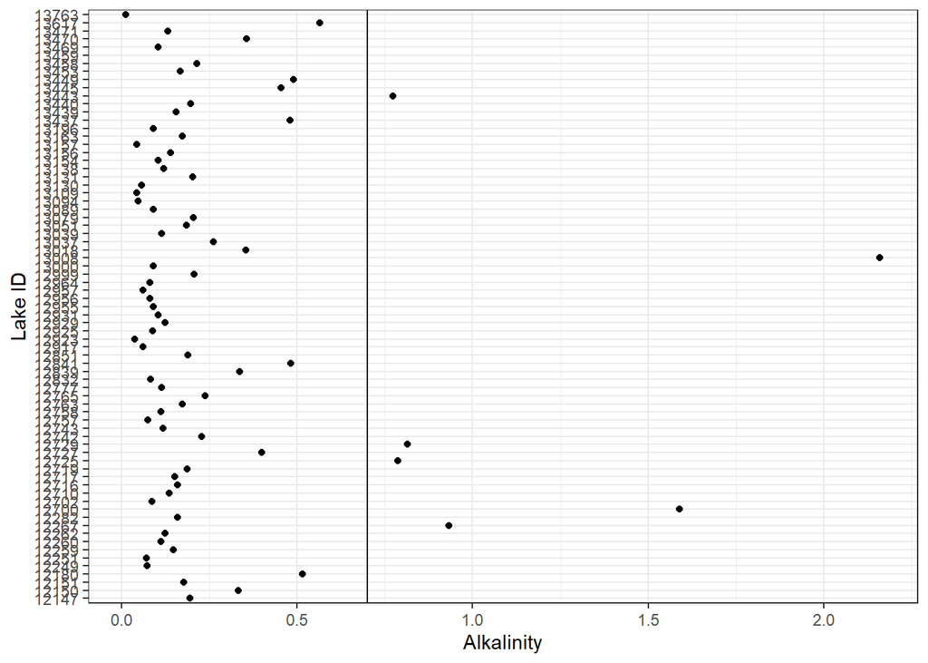

```r
ggplot(cba.all)+geom_point(aes(x = Alkalinity, y = as.character(Lake_ID)))+geom_vline(xintercept = 0.7)+labs(y="Lake ID")+theme_bw()
```

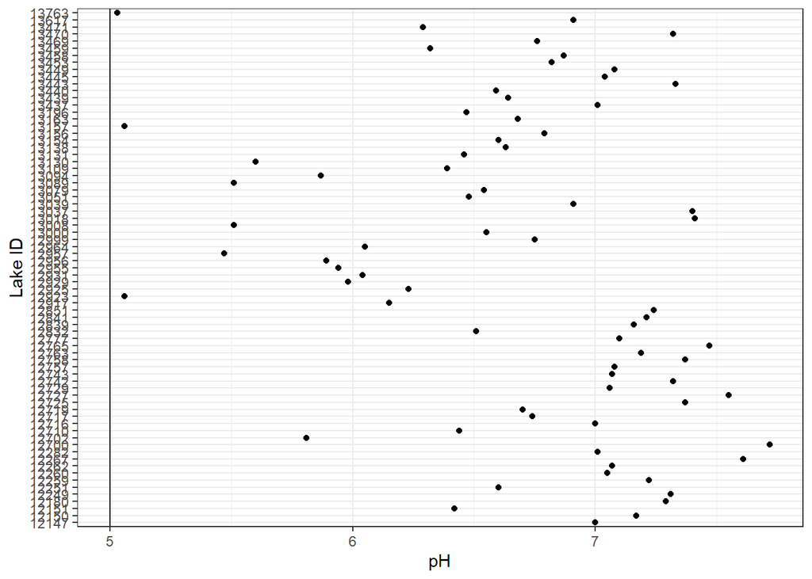

```r
ggplot(cba.all)+geom_point(aes(x = pH_Kje, y = as.character(Lake_ID)))+
  geom_vline(xintercept = 5)+labs(x = "pH", y="Lake ID")+theme_bw()
```

```r
bdg.niva <- readRDS("bdg.niva.rds") %>% dplyr::select(c("CBA_Lake_ID", "lake_area_km2","basin_area_km2"))

cba <- merge(cba.all,bdg.niva, by.x = "Lake_ID", by.y = "CBA_Lake_ID")
```

```r
nws.files <- list.files(path = "NWS", pattern = "Wind_WFDE5_CRU_2019", full.names = T)
nws.list.stacks <- lapply(nws.files, raster::stack) %>% lapply(raster::crop, c(0,35,55,73))
nws.list.means <- lapply(nws.list.stacks, raster::mean, na.rm = T)
saveRDS(nws.list.means, "cba.nws.list.mean.rds")
nws.2019 <- nws.list.means %>% raster::stack() %>% raster::mean()

cba.spdf <- SpatialPointsDataFrame(coords = cba[,c("Long","Lat")], data = cba[,c("Long","Lat","Lake_ID")], proj4string = CRS("+proj=longlat +datum=WGS84"))
annual.nws.cba <- raster::extract(nws.2019, cba.spdf, sp = T)

saveRDS(annual.nws.cba, "annual.nws.cba.rds")
```

The CBA dataset was then merged with the wind speed.

```r
annual.nws.cba <- readRDS("annual.nws.cba.rds")@data %>% select(c("Lake_ID","layer")) %>% setNames(c("Lake_ID","nws_m.s"))
cba <- cba %>%  merge(annual.nws.cba, by = "Lake_ID")
```

## 1.2 N112 data

This survey was first published in Larsen, Andersen, and Hessen (2011).

```r
n112.all <- read.table("Larsen/N112_subset_110909.txt", sep="", header = TRUE,na.strings = c(".", "NA"))

n112 <- n112.all %>% subset(ykoord > 6e6) %>% subset(is.na(TIC.ug) == F) %>% subset(is.na(alkendpoint) == F)

n112.spdf <- SpatialPointsDataFrame(coords = n112[,c("xkoord","ykoord")], data = n112[,c("xkoord","ykoord")], proj4string = CRS("+proj=utm +zone=32 +ellps=WGS84 +datum=WGS84 +units=m +no_defs"))
119
```

```
## [1] 119
```

```r
n112.spdf.wgs <- n112.spdf %>% spTransform(CRS("+proj=longlat +datum=WGS84"))
```

Similarly, the wind speed was aquired from Boogaard et al. (2020).

```r
nws.files <- list.files(path = "NWS", pattern = "Wind_WFDE5_CRU_2004", full.names = T)
nws.list.stacks <- lapply(nws.files, raster::stack) %>% lapply(raster::crop, c(0,35,55,73))
nws.list.means <- lapply(nws.list.stacks, raster::mean, na.rm = T)
saveRDS(nws.list.means, "n112.nws.list.mean.rds")

nws.list.mean <- readRDS("n112.nws.list.mean.rds")
nws.2004 <- nws.list.mean %>% raster::stack() %>% raster::mean()

n112.spdf <- SpatialPointsDataFrame(coords = n112[,c("xkoord","ykoord")], data = n112[,c("xkoord","ykoord","Vatnlnr")], proj4string = CRS("+proj=utm +zone=32 +ellps=WGS84 +datum=WGS84 +units=m +no_defs"))

annual.nws.n112 <- raster::extract(nws.2004, n112.spdf, sp = T)

saveRDS(annual.nws.n112, "annual.nws.n112.rds")
```

Then the original dataset was merged with the wind speed.

```r
annual.nws.n112 <- readRDS("annual.nws.n112.rds")@data %>% dplyr::select(c("Vatnlnr","layer")) %>% setNames(c("Vatnlnr","nws_m.s"))

n112 <- merge(n112, annual.nws.n112, by = "Vatnlnr")
```

## 1.3 Merge CBA and N112 data

Both dataset were merged in one. Concentration of TOC, TIC and other elements were converted in mol/L.

```r
norway <- data.frame(survey = c(rep("CBA_2019", dim(cba)[1]),rep("N112_2004",dim(n112)[1])))

norway$lake.id <- c(cba$Lake_ID,
                    n112$Vatnlnr)

norway$lake.name <- c(cba$Lake_name,
                      rep(NA,dim(n112)[1]))

norway$TOC <- c(cba$TOC/12.011 * 1e-3, # mg/L to mol/L
                n112$TOC/12.011 * 1e-3) # mg/L to mol/L

norway$TIC <- c(rep(NA, dim(cba)[1]),
                n112$TIC.ug/12.011 * 1e-6) # ug/L to mol/L

norway$Ca <- c(cba$Ca / 40.78 * 1e-3, #mg/L to mol/L
                rep(NA, dim(n112)[1])) # ug/L to mol/L

norway$TN <- c(cba$TN / 14 * 1e-3, #mg/L to mol/L
                n112$TotN / 14 * 1e-6) # ug/L to mol/L

norway$Fe <- c(cba$Fe / 55.845 * 1e-3, #mg/L to mol/L
                rep(NA, dim(n112)[1]))

norway$TA <- c(cba$Alkalinity * 1e-3, # convert from meq/L to mol/L
               n112$alkendpoint * 1e-6) # assumes ueq/L to mol/L,

norway$temp_c <- c(cba$T,
                   n112$temp.situ)

norway$temp_k <- norway$temp_c + 273.15

norway$EC <- c(cba$EC_Kje,
               rep("NA",dim(n112)[1])) %>% as.numeric()

norway$IS <- 1.3e-5 * norway$EC

norway$fCO2.atm <- c(rep(fCO2.atm.2019, dim(cba)[1]),
                     rep(rep(fCO2.atm.2004,dim(n112)[1])))

norway$pH <- c(cba$pH_Kje,
               n112$pH)

norway$Hplus <- 10^(-norway$pH)

norway$CO2 <- c(as.numeric(cba$CO2) * 1e-6, # from umol/L to mol/L
                n112$co2.umolar * 1e-6) # umol/L to mol/kg_solution

norway$long <- c(cba$Long,
                 n112.spdf.wgs@coords[,1])

norway$lat <- c(cba$Lat,
                 n112.spdf.wgs@coords[,2])

norway$lake.area <- c(cba$lake_area_km2,
                      n112$lake.area)

norway$catchment.area <- c(cba$basin_area_km2,
                      n112$poly.area)

norway$nws_m.s <- c(cba$nws_m.s,
                    n112$nws_m.s)

norway <- filter(norway, !is.na(TA))
```

We calculated the dissociation constants for the carbonate equilibrium based on Dickson and Riley (1979), Herbert S. Harned and Scholes (1941), Herbert S. Harned and Davis (1943) and Weiss (1974).

```r
norway$Kw = with(norway, exp(148.9802 - 13847.26/temp_k - 23.6521*log(temp_k))) # Dickson and Riley, 1979

#norway$K0 <- with(norway, 10^-((-2622.38/temp_k) + 15.5873 - 0.0178471*temp_k)) #Harned and Davis, 1943
norway$K0 <- with(norway, exp(-58.0931+90.5069*100/temp_k+22.2940*log(temp_k/100))) # Weiss 1974
norway$K1 <- with(norway, 10^-((3404.71/temp_k)- 14.8435 + 0.032786*temp_k)) # Harned and Davis, 1943
norway$K2 <- with(norway, 10^-((2902.39/temp_k) - 6.4980 + 0.02379*temp_k)) # Harned and Scholes, 1941
```

## 1.4 Carbonate speciation from measured CO2

Our datasets contain CO2 concentration calculated from total inorganic carbon, following the methods suggested by Sobek et al. (2003) for the N112 survey and Åberg and Wallin (2014) for the CBA survey.

The concentration of each carbonate species was calculated based on this value.

```r
norway$H2CO3 <- norway$CO2 # in mol/L
norway$HCO3 <- with(norway, H2CO3 * K1 / Hplus)
norway$CO3 <- with(norway, K2 * HCO3 / Hplus)

norway$fCO2 <- with(norway, CO2 / K0)
norway$dfCO2 <- with(norway, fCO2 - fCO2.atm)

norway$OH <- with(norway, Kw/Hplus)

# Check
norway$DIC <- with(norway, H2CO3 + HCO3 + CO3)
norway$CA <- with(norway,  HCO3 + 2*CO3)
```

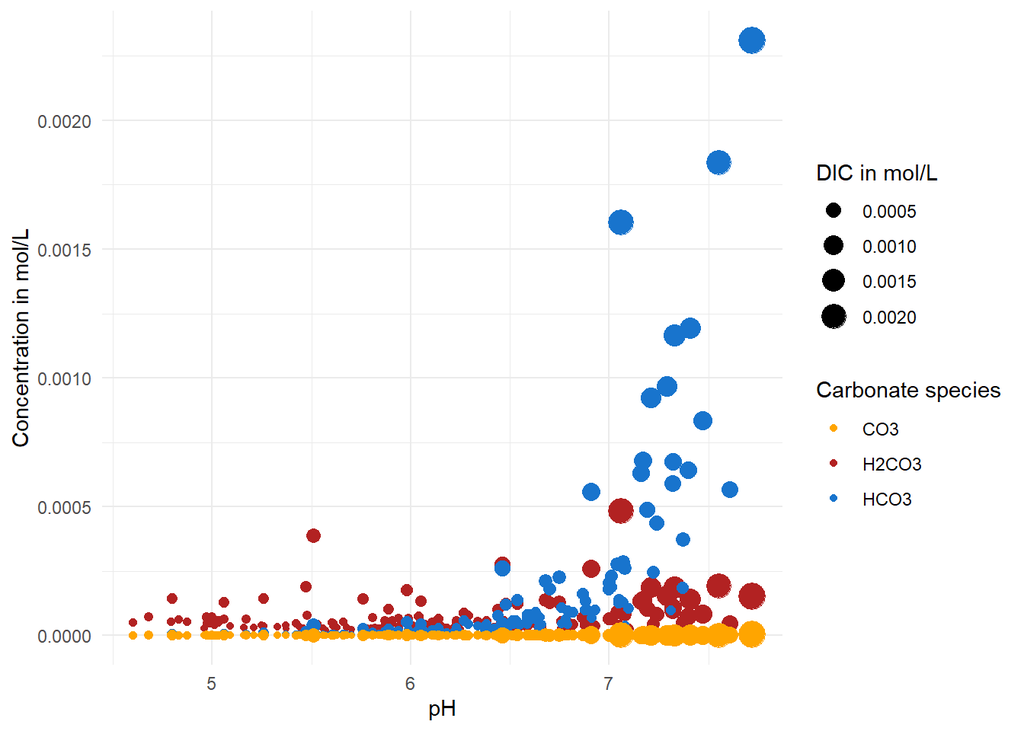

```r
ggplot(norway, aes(x = pH))+geom_point(aes(y = H2CO3, col = "H2CO3", size = DIC))+
  geom_point(aes(y = HCO3, col = "HCO3", size = DIC))+
  geom_point(aes(y = CO3, col = "CO3", size = DIC))+
  scale_color_manual(values = c("orange","firebrick","dodgerblue3"))+
  labs(y= "Concentration in mol/L", col = "Carbonate species", size = "DIC in mol/L")+
  theme_minimal()
```

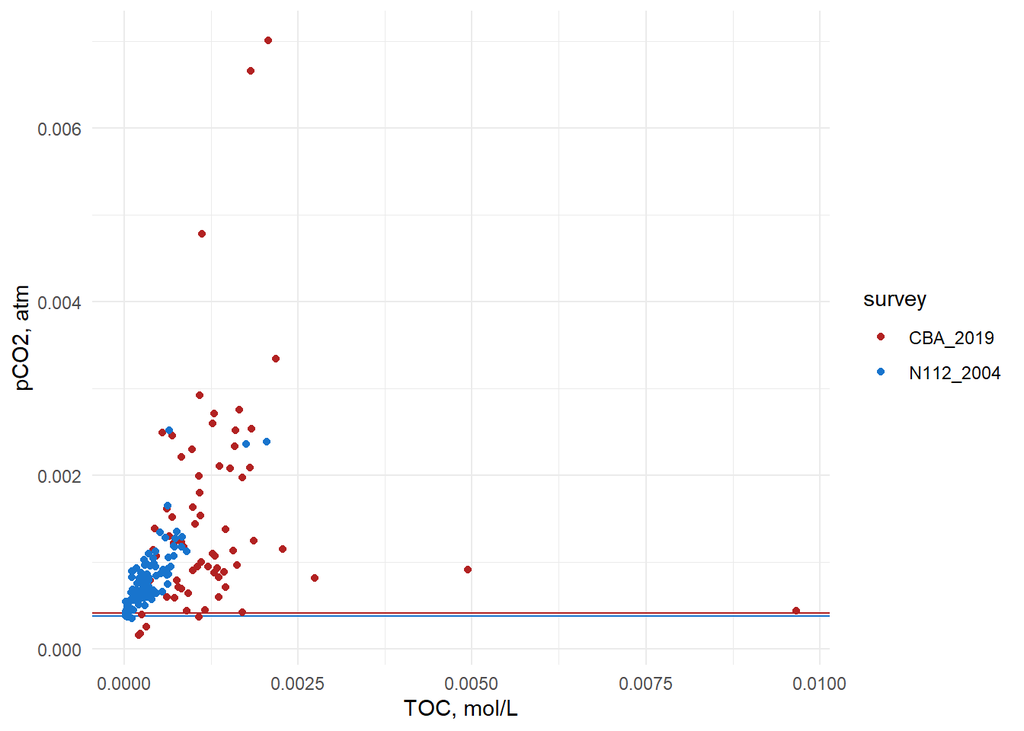

```r
ggplot(norway, aes(x = TOC, y = fCO2, col = survey))+
  geom_hline(yintercept = fCO2.atm.2019, col = "firebrick")+
  geom_hline(yintercept = fCO2.atm.2004, col = "dodgerblue3")+
  scale_color_manual(values = c("firebrick","dodgerblue3"))+
  #coord_trans(x = "log10")+
  geom_point()+
  labs(y = "pCO2, atm", x = "TOC, mol/L")+
  theme_minimal()
```

## 1.5 Carbonate speciation from TA

The concentration of each carbonate species is then calculated based on total alkalinity as a proxy for $HCO_3^- + 2 \times CO_3^{2-}$. The resulting pCO2 is also calculated.

```r
norway$ta_CO3 <- with(norway,(TA - OH + Hplus) / (Hplus/K2 +2)) # in mol/L
norway$ta_HCO3 <- with(norway, ta_CO3*Hplus/K2)
norway$ta_H2CO3 <- with(norway, ta_HCO3*Hplus/K1)
norway$ta_fCO2 <- with(norway,ta_H2CO3/K0)

norway$ta_DIC <- with(norway, ta_H2CO3 + ta_HCO3 + ta_CO3)
```

## 1.6 Save test dataset

The dataset is saved under the name “norway”.

```r
saveRDS(norway,"norway.rds")
```

# 2 Northern Lakes Survey

The dataset from the Northern Europeal Lakes Survey Henriksen et al. (1998) is used as a training dataset. Additionnaly, it constitutes the basis for calculating national evasion rates in Norway, Sweden and Finland.

## 2.1 Download from NOFA database

The data is available in the NOFA database (Finstad 2017), including catchment polygons.

Measurements methods for the Northern Lakes Survey are detailed in Henriksen et al. (1996). Alkalinity is detailed in Annex 3. “alk_e” is a the variable corresponding to the alkalinity calibrated, taking into account the account the different methods used in Norway, Sweden and Finland.

```r
con <- DBI::dbConnect(RPostgreSQL::PostgreSQL(),user = "camille.crapart", password = "camille",host = "vm-srv-wallace.vm.ntnu.no", dbname = "nofa")

ion <- tbl(con, sql("SELECT gid, ebint,nation,date,temp_c,latitude,longitude,ph,alk_e_ueq_l,alk_subst,k25_ms_m,ca_ueq_l,mg_ueq_l,na_ueq_l,k_ueq_l,nh4_ueq_l,cl_ueq_l,so4_ueq_l,no3_ueq_l,f_ueq_l,tot_p_ug_l,tot_n_ug_l,toc_mg_l,dist_closest_ebint,dist_2nd_closest_ebint FROM environmental.north_euro_lake_surv_1995 ")) %>% as.data.frame()
names(ion) <- c("gid", "ebint","nation","date","temp_c","latitude","longitude","ph","alk_ueq","alk","cond","ca","mg","na","k","nh4","cl","so4","no3","f","tp","tn","toc","dist_closest_ebint","dist_2nd_closest_ebint")
saveRDS(ion,"ion.rds")

lakes <- st_read(con,query = "SELECT gid, ebint, geom, area, perimtot FROM environmental.ecco_biwa_lakes_v_0_1 WHERE ebint IN (SELECT ebint FROM environmental.north_euro_lake_surv_1995)")
saveRDS(lakes,"lakes.rds")

catchments <- st_read(con,query = "SELECT ebint, geom FROM catchments.lake_catchments WHERE ebint IN (SELECT ebint FROM environmental.north_euro_lake_surv_1995)") # in UTM33
saveRDS(catchments,"catchments.rds")
catchment.poly <- st_transform(catchments, crs = st_crs("EPSG:4326")) # converts in World Geodetic System 1984
saveRDS(catchment.poly,"catchment.poly.rds")
catchment.poly.corine <- st_transform(catchment.poly, crs = st_crs("EPSG:3035")) # converts to EU extended referential ETRS89-extended
saveRDS(catchment.poly.corine, "catchment.poly.corine.rds")
```

## 2.2 Near surface wind speed

Wind speed data is acquired from Boogaard et al. (2020). Lakes from the NLS survey are larger than for the CBA and N112 survey. Therefore, we averaged the wind speed for the year and for the total area of the lakes.

```r
lakes <- readRDS("lakes.rds")

nws.files <- list.files(path = "NWS", pattern = "Wind_WFDE5_CRU_1995", full.names = T)
nws.list.stacks <- lapply(nws.files, raster::stack) %>% lapply(raster::crop, c(0,35,55,73))
nws.list.means <- lapply(nws.list.stacks, raster::mean, na.rm = T)
saveRDS(nws.list.means, "nlss.nws.list.mean.rds")

nws.list.mean <- readRDS("nlss.nws.list.mean.rds")
nws.1995 <- nws.list.mean %>% raster::stack() %>% raster::mean()

annual.nws.1995 <- raster::extract(nws.1995, lakes,fun = mean, na.rm = T, df = T)
annual.nws.1995$ebint <- lakes$ebint

saveRDS(annual.nws.1995, "annual.nws.nls.rds")
```

## 2.3 Merge data for NLS

We merged the different datasets related to the NLS. Lakes with TOC and TP concentration inferior to 0 were removed (we assumed measurement errors in these lakes).

```r
ion <- readRDS("ion.rds")
lakes <- readRDS("lakes.rds")
nws <- readRDS("annual.nws.nls.rds") %>% setNames(c("ID","nws_m.s","gid","ebint"))

nls <- merge(ion, lakes, by = "ebint") %>% merge(nws, by= "ebint")

nls$uncertain <- ifelse(nls$dist_closest_ebint/nls$dist_2nd_closest_ebint > 0.5, FALSE, TRUE)
nls$uncertain[which(is.na(nls$uncertain)==TRUE)] <- FALSE

nls$temp_c[which(is.na(nls$temp_c)==T)] <- 4

nls <- nls %>% filter(toc >= 0) %>% filter(tp > 0) %>% filter(uncertain == FALSE)

saveRDS(nls,"nls.rds")
```

A simplified dataframe is created, with a selection of variables matching the variables used in the CBA and N112 survey. TOC and alkalinity are converted in mol/L.

```r
nls <- readRDS("nls.rds")

nlss <- data.frame(lake.id = nls$ebint)

nlss$pH <- nls$ph
nlss$Hplus <- 10^(-nlss$pH)
nlss$TA <- nls$alk_ueq * 1e-6
nlss$TOC <- nls$toc / 12.011 * 1e-3
nlss$nws_m.s <- nls$nws_m.s

nlss$long <- nls$longitude
nlss$lat <- nls$latitude
nlss$fCO2.atm <- fCO2.atm.1995

nlss$temp_c <- nls$temp_c
nlss$temp_k <- nls$temp_c + 273.15

nlss$lake.area <- nls$area * 1e-6 # m2 to km2

nlss$nation <- nls$nation
```

The dissociation constants are calculated as previously.

```r
nlss$Kw = with(nlss, exp(148.9802 - 13847.26/temp_k - 23.6521*log(temp_k))) # Dickson and Riley, 1979

#nlss$K0 <- with(nlss, 10^-((-2622.38/temp_k) + 15.5873 - 0.0178471*temp_k)) #Harned and Davis, 1943
nlss$K0 <- with(nlss, exp(-58.0931+90.5069*100/temp_k+22.2940*log(temp_k/100))) # Weiss 1974
nlss$K1 <- with(nlss, 10^-((3404.71/temp_k)- 14.8435 + 0.032786*temp_k)) # Harned and Davis, 1943
nlss$K2 <- with(nlss, 10^-((2902.39/temp_k) - 6.4980 + 0.02379*temp_k)) # Harned and Scholes, 1941


nlss$OH <- with(nlss, Kw/Hplus)
```

## 2.4 Save NLS

The final dataframe is saved under the name “nlss”.

```r
duplicated.id <- nlss$lake.id[which(duplicated(nlss$lake.id) == T)]
nlss[nlss$lake.id %in% duplicated.id, ]
```

```
##       lake.id   pH        Hplus       TA          TOC    long     lat
## 49     198840 7.22 6.025596e-08 0.000194 0.0003496795 17.3300 66.3063
## 50     198840 7.13 7.413102e-08 0.000139 0.0001165598 17.8765 66.0607
## 51     198840 7.43 3.715352e-08 0.000320 0.0002164682 17.3472 66.2360
## 164    650780 7.20 6.309573e-08 0.000230 0.0004246108 24.1500 61.2911
## 165    650780 7.10 7.943282e-08 0.000180 0.0004662393 24.3442 61.5383
## 871   3482384 6.52 3.019952e-07 0.000091 0.0012155524 15.9238 62.0552
## 872   3482384 6.56 2.754229e-07 0.000109 0.0009491300 15.9285 62.0575
## 1026  4136486 6.45 3.548134e-07 0.000103 0.0008325701 14.1278 56.6480
## 1027  4136486 6.30 5.011872e-07 0.000098 0.0008408958 14.1248 56.6650
## 1155  4661711 7.00 1.000000e-07 0.000032 0.0003247024 12.7508 62.2453
## 1156  4661711 6.91 1.230269e-07 0.000085 0.0002331196 12.7677 62.2355
## 1442  5862036 6.90 1.258925e-07 0.000220 0.0003413538 28.5317 66.0217
## 1443  5862036 7.50 3.162278e-08 0.000250 0.0003247024 28.6525 66.1139
## 1645  6657392 7.00 1.000000e-07 0.000130 0.0004162851 28.0128 66.3794
```

[output cut: 79 more lines]

```r
unique.nlss <- nlss %>% group_by(lake.id, nation) %>% summarise_all(median)
```

```r
saveRDS(unique.nlss, "nlss.rds")
```

Åberg, Jan, and Marcus B. Wallin. 2014. “Evaluating a fast headspace method for measuring DIC and subsequent calculation of pCO2 in freshwater systems.” *Inland Waters* 4 (2): 157–66. https://doi.org/10.5268/IW-4.2.694.

Boogaard, H., J. Schubert, A. De Wit, J. Lazebnik, R. Hutjes, and G. Van der Grijn. 2020. “Copernicus Climate Change Service (C3S) Climate Data Store (CDS).” https://doi.org/10.24381/cds.6c68c9bb.

Crapart, Camille, and Nicolas Parra. 2019. “CBA 100 lakes.” https://osf.io/r39ng/?view_only=d1b8c4c2c68c4ca59bb4c78a817fc64b.

Dickson, A. G., and J. P. Riley. 1979. “The estimation of acid dissociation constants in seawater media from potentionmetric titrations with strong base. I. The ionic product of water - Kw.” *Marine Chemistry* 7 (2): 89–99. https://doi.org/10.1016/0304-4203(79)90001-X.

Finstad, Anders G. 2017. “Environmental data NINAnor/NOFA Wiki.” https://github.com/NINAnor/NOFA/wiki/Environmental-data.

Harned, Herbert S., and Raymond Davis. 1943. “The Ionization Constant of Carbonic Acid in Water and the Solubility of Carbon Dioxide in Water and Aqueous Salt Solutions from 0 to 50°.” *Journal of the American Chemical Society* 65 (10): 2030–37. https://doi.org/10.1021/ja01250a059.

Harned, Herbert S, and Samuel R Scholes. 1941. “The ionization Constant of HCO3- from 0 to 50°.” *Journal of American Chemical Society* 63 (6): 1706–9. https://pubs.acs.org/sharingguidelines.

Henriksen, Arne, Brit Lisa Skjelvåle, Leif Lien, Tor S Traaen, Jaakko Mannio, Martin Forsius, J Kämari, et al. 1996. “Regional Lake Surveys in Finland - Norway - Sweden - Northern Kola - Russian Karelia - Scotland - Wales 1995, Coordination and design.” NIVA. https://niva.brage.unit.no/niva-xmlui/bitstream/handle/11250/208733/3420_72dpi.pdf?sequence=1&isAllowed=y.

Henriksen, Arne, Brit Lisa Skjelvåle, Jaakko Mannio, Anders Wilander, Ron Harriman, Chris Curtis, Jens Peder Jensen, Erik Fjeld, and Tatyana Moiseenko. 1998. “Northern European Lake Survey 1995: Finland, Norway, Sweden, Denmark, Russian Kola, Russian Karelia, Scotland and Wales.” *Ambio* 2 (27): 80–91. https://www.jstor.org/stable/4314692.

Larsen, Søren, Tom Andersen, and Dag O. Hessen. 2011. “The pCO2 in boreal lakes: Organic carbon as a universal predictor?” *Global Biogeochemical Cycles* 25 (2): 1–8. https://doi.org/10.1029/2010GB003864.

Sobek, Sebastian, Grete Algesten, Ann Kristin Bergström, Mats Jansson, and Lars J. Tranvik. 2003. “The catchment and climate regulation of pCO2 in boreal lakes.” *Global Change Biology* 9 (4): 630–41. https://doi.org/10.1046/j.1365-2486.2003.00619.x.

Weiss, R. F. 1974. “Carbon dioxide in water and seawater: the solubility of a non-ideal gas.” *Marine Chemistry* 2: 203–15. https://doi.org/10.5194/bg-13-841-2016.